# Longitudinal Clustering

Applied Machine Learning in Economics

I love longitudinal clustering! When there is something there, it is just so cool! We are going to use a new technique called the gap statistic to identify the number of clusters in the data. We want the largest value. I will discuss what is going on under the hood with the gap statistic in the live lecture.

The general idea is exactly the same as before. The only difference is in the interpretation of our “variables”. Normally, a correctly formatted data set would have one time observation per row (long formatted data). Instead, we are going to create a different variables for each time period (wide formatted data).

We will be working with weekly COVID19 new cases using `time_series_covid19_confirmed_US.csv` from https://github.com/CSSEGISandData/COVID-19. It will take a bit of wrangling to get into a workable format. The algorithm needs the data to be in a “wide” format. Creating weekly averages and plotting requires a “long” format. We are going to look from the beginning of March through October.

**An important note on scaling:** We are going to standardize these data for different states. However, given the context of these data, it would perhaps make more sense to do a more specific scaling such as new cases per capita to allow for comparison across states. Standardizing only allows us to compare shapes, not levels.

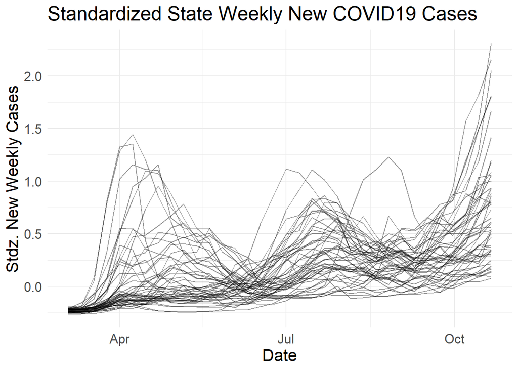

```r
library(cluster)
library(data.table)
library(lubridate)
library(tidyverse)
set.seed(490)

setwd('C:/Users/johnj/Documents/Data/COVID-19/csse_covid_19_data/csse_covid_19_time_series')

covid = fread('time_series_covid19_confirmed_US.csv')
names(covid) = names(covid) %>% tolower

# A color blind friendly palette
cbPalette <- c("#E69F00", "#56B4E9", "#009E73", "#F0E442", "#0072B2", "#D55E00", "#CC79A7")

# The wrangle!
plt = covid %>%
  mutate(state = province_state) %>%
  filter(code3 == 840 &
           # Removing cruise liners Grand Princess and Diamond Princess
           !grepl('prince', state, ignore.case = TRUE)) %>%
  # Selecting March through October
  select(state, "3/1/20":"10/31/20") %>%
  # Pivoting longer so we can convert to week sums
  # and then difference for new cases
  # and then standardize
  pivot_longer(-state, names_to = 'date', values_to = 'cases') %>%
  mutate(date = mdy(date)) %>%            # lubridate
  group_by(week = week(date), state) %>%  # lubridate
  summarise(cases = sum(cases)) %>%
  group_by(state) %>%
  mutate(new = c(0,diff(cases)),
         new_std = c(scale(new))) %>%
  filter(week != 9 & week != 44) %>% # Removing incomplete weeks
  mutate(date = ymd('2020-01-01') + weeks(week - 1)) %>%
  select(state, date, new_std)


ggplot(plt, aes(x = date, y = new_std, group = state)) +
  geom_line(alpha = 0.4) +
  theme_minimal() +
  theme(text = element_text(size = 16)) +
  labs(x = 'Date', y = 'Stdz. New Weekly Cases', title = 'Standardized State Weekly New COVID19 Cases')
```

Yeah… I cannot tell which lines belong to which in that figure. Thank goodness for clustering! Let’s pivot wider to do some clustering!

```r
clst = plt %>%
  pivot_wider(id_cols = state, names_from = 'date', values_from = 'new_std')
```

# K-Means

Remember, we are going to be using a technique called the gap statistic. It uses bootstrapping to create standard errors for each estimate. Then we choose the highest. Specifically, we should choose the number of clusters identified that is the maximum cluster’s value minus its standard error. This will make more sense below.

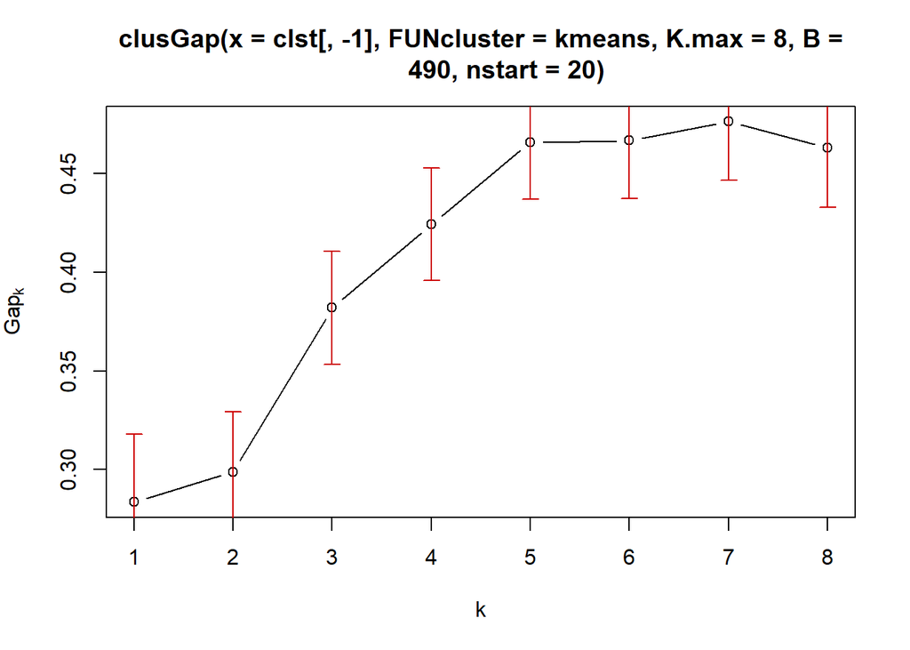

```r
cl_k = clusGap(clst[, -1], FUN = kmeans, nstart = 20, K.max = 8, B = 490)
plot(cl_k)
```

Or if we wanted to make this plot in `ggplot2`, we can do the following. Note that there is way more customization that we could do.

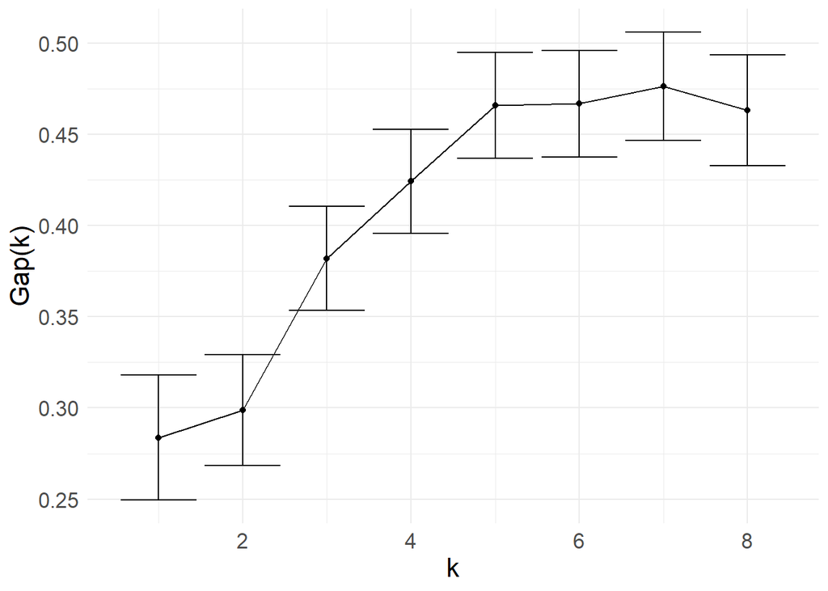

```r
df = data.frame(cl_k$Tab)
ggplot(df, aes(x = c(1:nrow(df)), y = gap)) +
  geom_line() +
  geom_point() +
  geom_errorbar(aes(ymin = gap - SE.sim, ymax = gap + SE.sim)) +
  labs(y = 'Gap(k)', x = 'k') +
  theme_minimal() +
  theme(text = element_text(size = 16))
```

## Using the Gap Statistic

From the figure above, we can see the global max is 7. However, 5 is basically just as good as 7. We can tell by the standard error bars.

```r
print(cl_k, method = 'globalmax')   # 7 is the best
```

```
## Clustering Gap statistic ["clusGap"] from call:
## clusGap(x = clst[, -1], FUNcluster = kmeans, K.max = 8, B = 490,     nstart = 20)
## B=490 simulated reference sets, k = 1..8; spaceH0="scaledPCA"
##  --> Number of clusters (method 'globalmax'): 7
##          logW   E.logW       gap     SE.sim
## [1,] 3.214105 3.497742 0.2836369 0.03425153
## [2,] 2.984281 3.283193 0.2989119 0.03036417
## [3,] 2.774048 3.156020 0.3819726 0.02853916
## [4,] 2.637576 3.061746 0.4241707 0.02838811
## [5,] 2.520196 2.985993 0.4657976 0.02899012
## [6,] 2.452253 2.918934 0.4666807 0.02932198
## [7,] 2.381512 2.857755 0.4762433 0.02970065
## [8,] 2.336854 2.799903 0.4630482 0.03029675
```

```r
print(cl_k, method = 'globalSEmax') # 5 is the actual best
```

```
## Clustering Gap statistic ["clusGap"] from call:
## clusGap(x = clst[, -1], FUNcluster = kmeans, K.max = 8, B = 490,     nstart = 20)
## B=490 simulated reference sets, k = 1..8; spaceH0="scaledPCA"
##  --> Number of clusters (method 'globalSEmax', SE.factor=1): 5
##          logW   E.logW       gap     SE.sim
## [1,] 3.214105 3.497742 0.2836369 0.03425153
## [2,] 2.984281 3.283193 0.2989119 0.03036417
## [3,] 2.774048 3.156020 0.3819726 0.02853916
## [4,] 2.637576 3.061746 0.4241707 0.02838811
## [5,] 2.520196 2.985993 0.4657976 0.02899012
## [6,] 2.452253 2.918934 0.4666807 0.02932198
## [7,] 2.381512 2.857755 0.4762433 0.02970065
## [8,] 2.336854 2.799903 0.4630482 0.03029675
```

## Fitting Identified Model

From here, we have to refit the model. Remember that the data begin randomly assigned to a cluster and then are reassigned at each iteration. Here’s to hoping we identify the same clusters!

```r
fit_k = kmeans(clst[, -1], 5, nstart = 20)
fit_k$cluster
```

```
##  [1] 1 4 1 3 1 3 5 2 2 1 1 3 3 2 3 3 3 3 1 2 2 5 2 3 1 3 4 3 1 2 5 3 5 1 4 3 3 1
## [39] 2 2 1 4 1 1 3 5 2 1 3 4 4
```

## Plotting

Let’s make a plot based upon the clusters identified.

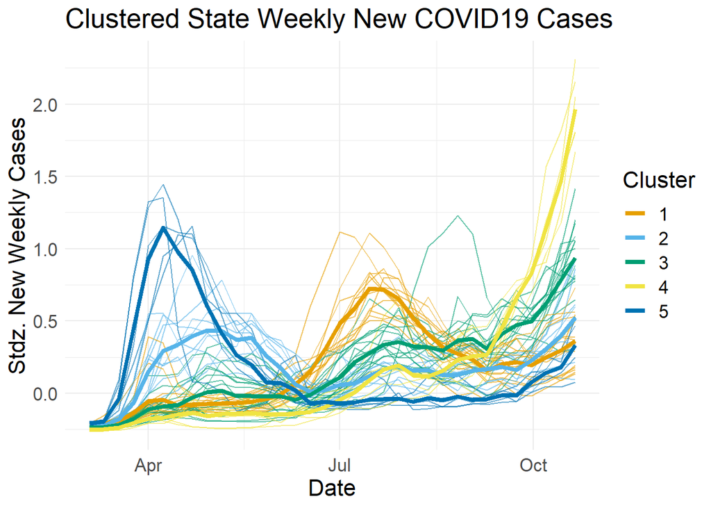

```r
lbls = data.frame(state = clst$state, cluster = fit_k$cluster)
plt_k = left_join(plt, lbls)
avgs = plt_k %>%
  group_by(date, cluster) %>%
  summarize(average = mean(new_std))
ggplot() +
  geom_line(data = plt_k, aes(x = date, y = new_std, group = state, color = as.factor(cluster)),
            alpha = 0.6) +
  geom_line(data = avgs, aes(x = date, y = average, color = as.factor(cluster)),
            size = 1.5) +
  scale_color_manual(values = cbPalette) +
  theme_minimal() +
  theme(text = element_text(size = 16)) +
  labs(x = 'Date', y = 'Stdz. New Weekly Cases', title = 'Clustered State Weekly New COVID19 Cases', color = 'Cluster')
```

# Partitioning Around Medoids

Partitioning Around Medoids is another unsupervised learning technique that is more robust than K-means. The function `pam` can take `dist` objects, which allows for alternative types such as the correlation distance.

## Euclidean Distance

Let’s just use the base distance first.

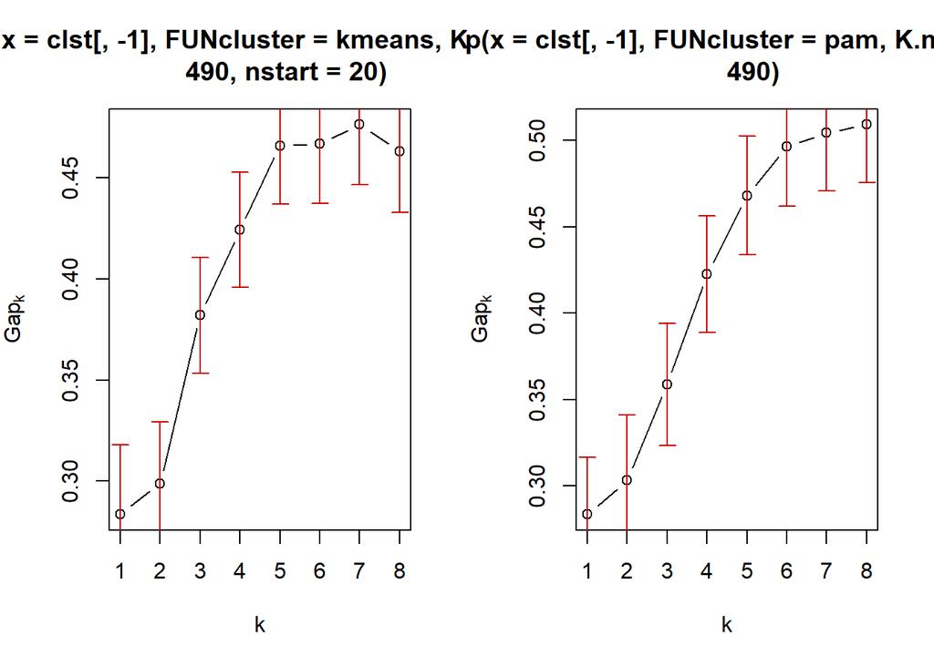

```r
cl_p = clusGap(clst[, -1], FUN = pam, K.max = 8, B = 490)
par(mfrow = c(1,2))
plot(cl_k); plot(cl_p)
```

```r
par(mfrow = c(1,1))
print(cl_p, method = 'globalSEmax')
```

```
## Clustering Gap statistic ["clusGap"] from call:
## clusGap(x = clst[, -1], FUNcluster = pam, K.max = 8, B = 490)
## B=490 simulated reference sets, k = 1..8; spaceH0="scaledPCA"
##  --> Number of clusters (method 'globalSEmax', SE.factor=1): 6
##          logW   E.logW       gap     SE.sim
## [1,] 3.214105 3.497554 0.2834490 0.03293223
## [2,] 2.998388 3.301591 0.3032035 0.03781402
## [3,] 2.822416 3.181172 0.3587567 0.03551284
## [4,] 2.666032 3.088728 0.4226953 0.03380840
## [5,] 2.545566 3.013709 0.4681434 0.03438158
## [6,] 2.450939 2.947517 0.4965783 0.03459829
## [7,] 2.382320 2.886750 0.5044299 0.03376588
## [8,] 2.320974 2.830246 0.5092719 0.03362551
```

Here it identified 6 clusters as optimal, however, we are going to use 5 for comparability to the K-means method.

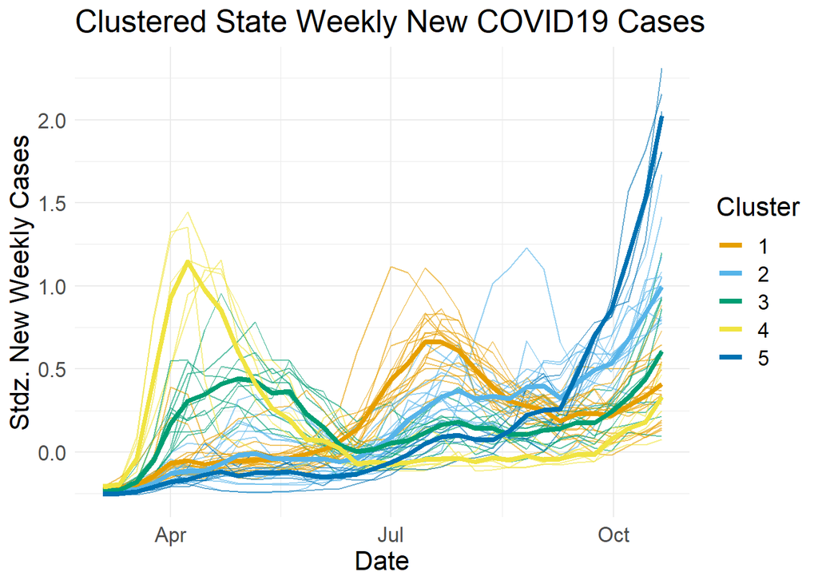

```r
fit_p = pam(clst[, -1], 5)
lbls = data.frame(state = clst$state, cluster = fit_p$clustering)
plt_p = left_join(plt, lbls)
avgs = plt_p %>%
  group_by(date, cluster) %>%
  summarize(average = mean(new_std))
ggplot() +
  geom_line(data = plt_p, aes(x = date, y = new_std, group = state, color = as.factor(cluster)),
            alpha = 0.6) +
  geom_line(data = avgs, aes(x = date, y = average, color = as.factor(cluster)),
            size = 1.5) +
  scale_color_manual(values = cbPalette) +
  theme_minimal() +
  theme(text = element_text(size = 16)) +
  labs(x = 'Date', y = 'Stdz. New Weekly Cases', title = 'Clustered State Weekly New COVID19 Cases', color = 'Cluster')
```

This produces a very similar figure. Remember that the whatever number the cluster gets is irrelevant.

Out of curiousity, what states end up in what cluster?

```r
lbls %>% arrange(cluster)
```

```
##                   state cluster
## 1               Alabama       1
## 2               Arizona       1
## 3              Arkansas       1
## 4            California       1
## 5               Florida       1
## 6               Georgia       1
## 7             Louisiana       1
## 8           Mississippi       1
## 9                Nevada       1
## 10       North Carolina       1
## 11                 Ohio       1
## 12               Oregon       1
## 13       South Carolina       1
## 14            Tennessee       1
```

[output cut: 37 more lines]

## Correlation Distance

Here is how you implement clustering with a correlation measure of dissimilarity.

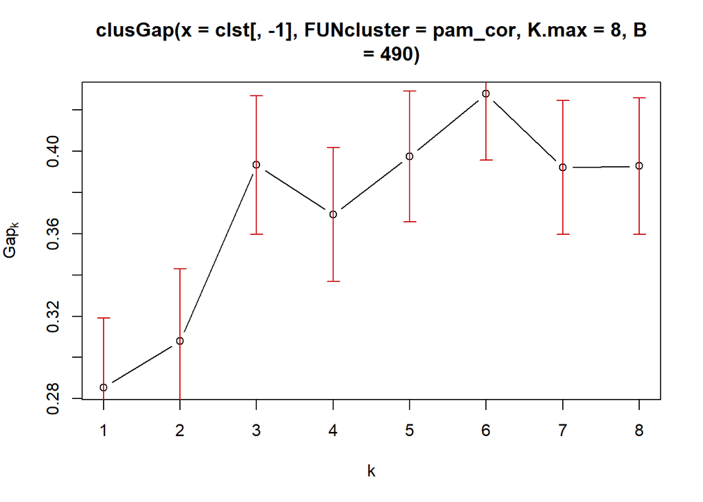

```r
pam_cor = function(x, k){
  list(cluster = pam(as.dist(1 - cor(t(x))), k = k, diss = TRUE, cluster.only = TRUE))
}

cl_pc = clusGap(clst[, -1], FUN = pam_cor, K.max = 8, B = 490)
plot(cl_pc)
```

```r
print(cl_pc, method = 'globalSEmax')
```

```
## Clustering Gap statistic ["clusGap"] from call:
## clusGap(x = clst[, -1], FUNcluster = pam_cor, K.max = 8, B = 490)
## B=490 simulated reference sets, k = 1..8; spaceH0="scaledPCA"
##  --> Number of clusters (method 'globalSEmax', SE.factor=1): 5
##          logW   E.logW       gap     SE.sim
## [1,] 3.214105 3.499443 0.2853385 0.03372351
## [2,] 2.989628 3.297665 0.3080366 0.03493385
## [3,] 2.782355 3.175676 0.3933214 0.03360721
## [4,] 2.716766 3.086053 0.3692873 0.03243351
## [5,] 2.618006 3.015574 0.3975685 0.03171056
## [6,] 2.525000 2.952811 0.4278114 0.03203008
## [7,] 2.502417 2.894560 0.3921425 0.03244286
## [8,] 2.448206 2.841012 0.3928063 0.03301463
```

```r
dc = as.dist(1 - cor(t(clst[, -1])))


fit_pc = pam(dc, 5, diss = TRUE)
lbls = data.frame(state = clst$state, cluster = fit_pc$clustering)
plt_pc = left_join(plt, lbls)
avgs = plt_pc %>%
  group_by(date, cluster) %>%
  summarize(average = mean(new_std))
```

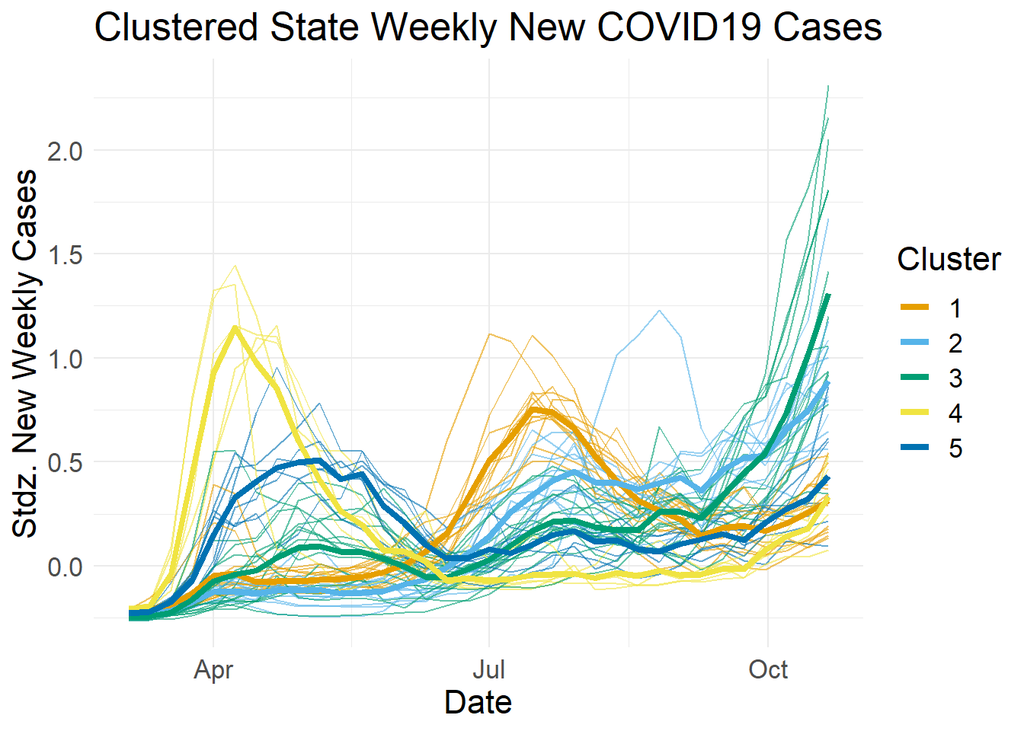

```r
ggplot() +
  geom_line(data = plt_pc, aes(x = date, y = new_std, group = state, color = as.factor(cluster)),
            alpha = 0.6) +
  geom_line(data = avgs, aes(x = date, y = average, color = as.factor(cluster)),
            size = 1.5) +
  scale_color_manual(values = cbPalette) +
  theme_minimal() +
  theme(text = element_text(size = 16)) +
  labs(x = 'Date', y = 'Stdz. New Weekly Cases', title = 'Clustered State Weekly New COVID19 Cases', color = 'Cluster')
```

# Hierarchical Clustering

And finally, here is how you perform hierarchical clustering.

**Q** Are we using euclidean or correlation distance?

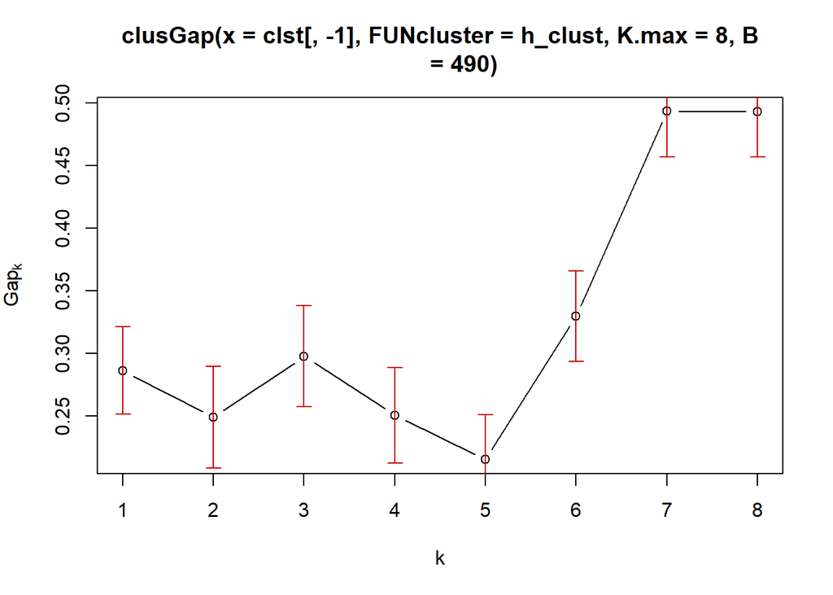

```r
h_clust = function(x, k){
  list(cluster = cutree(hclust(dist(x), method = 'average'), k = k))
}

cl_h = clusGap(clst[, -1], FUN = h_clust, K.max = 8, B = 490)
plot(cl_h)
```

```r
print(cl_h, method = 'globalSEmax')
```

```
## Clustering Gap statistic ["clusGap"] from call:
## clusGap(x = clst[, -1], FUNcluster = h_clust, K.max = 8, B = 490)
## B=490 simulated reference sets, k = 1..8; spaceH0="scaledPCA"
##  --> Number of clusters (method 'globalSEmax', SE.factor=1): 7
##          logW   E.logW       gap     SE.sim
## [1,] 3.214105 3.500397 0.2862917 0.03485289
## [2,] 3.054357 3.303668 0.2493114 0.04058057
## [3,] 2.897717 3.195367 0.2976495 0.04027997
## [4,] 2.851196 3.101869 0.2506733 0.03794435
## [5,] 2.813255 3.028624 0.2153690 0.03570576
## [6,] 2.634548 2.964223 0.3296749 0.03609982
## [7,] 2.410734 2.903972 0.4932380 0.03654287
## [8,] 2.352207 2.845251 0.4930439 0.03636268
```